# Frog Game Exploratory Data Analysis

JMG

2024-07-06

## Preprocess Data

### Let’s read the data in and make sure it looks normal

```r
data <- read.csv("/Users/jorgevargasmutizabal/Desktop/Data/R Analysis J/IN/nat.csv")
summary(data)
```

```
##    Player_ID        LexTale         Game_Version     Game_Level
##  Min.   : 1.00   Min.   :-11.000   Min.   :1.000   Min.   :1.000
##  1st Qu.:12.00   1st Qu.: -3.000   1st Qu.:2.000   1st Qu.:2.000
##  Median :21.00   Median :  1.000   Median :3.000   Median :4.000
##  Mean   :21.05   Mean   :  2.969   Mean   :2.695   Mean   :3.921
##  3rd Qu.:31.00   3rd Qu.:  8.000   3rd Qu.:4.000   3rd Qu.:6.000
##  Max.   :38.00   Max.   : 55.000   Max.   :4.000   Max.   :8.000
##  Phrase_Condition  Question_Num     Answer        Reaction_Time
##  Min.   :1.000    Min.   :  0.0   Mode :logical   Min.   : 0.0000
##  1st Qu.:2.000    1st Qu.: 64.0   FALSE:3994      1st Qu.: 0.5200
##  Median :3.000    Median :154.0   TRUE :18410     Median : 0.8000
##  Mean   :2.916    Mean   :163.2                   Mean   : 0.9436
##  3rd Qu.:4.000    3rd Qu.:249.0                   3rd Qu.: 1.1300
##  Max.   :4.000    Max.   :383.0                   Max.   :48.5000
```

### Define factors and numeric:

```r
#
str(data)
```

```
## 'data.frame':    22404 obs. of  8 variables:
##  $ Player_ID       : int  1 1 1 1 1 1 1 1 1 1 ...
##  $ LexTale         : int  8 8 8 8 8 8 8 8 8 8 ...
##  $ Game_Version    : int  1 1 1 1 1 1 1 1 1 1 ...
##  $ Game_Level      : int  1 1 1 1 1 1 1 1 1 1 ...
##  $ Phrase_Condition: int  1 1 1 1 1 1 1 1 1 1 ...
##  $ Question_Num    : int  0 1 2 3 4 5 6 7 8 9 ...
##  $ Answer          : logi  TRUE TRUE TRUE TRUE TRUE TRUE ...
##  $ Reaction_Time   : num  1.99 0.8 1.8 0.77 0.82 0.86 0.82 0.85 0.78 1.06 ...
```

```r
data <- data %>%
  mutate(
    Player_ID = as.factor(Player_ID),          # Convert to factor
    LexTale = as.numeric(LexTale),              # Convert to numeric
    Game_Version = as.factor(Game_Version),     # Convert to factor
    Game_Level = as.factor(Game_Level),        # Convert to factor
    Phrase_Condition = as.factor(Phrase_Condition), # Convert to factor
    Question_Num = as.numeric(Question_Num),    # Convert to numeric
    Answer = as.factor(Answer),                 # Convert to factor
    Reaction_Time = as.numeric(Reaction_Time)   # Convert to numeric
  )

# Verify changes
str(data)
```

```
## 'data.frame':    22404 obs. of  8 variables:
##  $ Player_ID       : Factor w/ 38 levels "1","2","3","4",..: 1 1 1 1 1 1 1 1 1 1 ...
##  $ LexTale         : num  8 8 8 8 8 8 8 8 8 8 ...
##  $ Game_Version    : Factor w/ 4 levels "1","2","3","4": 1 1 1 1 1 1 1 1 1 1 ...
##  $ Game_Level      : Factor w/ 8 levels "1","2","3","4",..: 1 1 1 1 1 1 1 1 1 1 ...
##  $ Phrase_Condition: Factor w/ 4 levels "1","2","3","4": 1 1 1 1 1 1 1 1 1 1 ...
##  $ Question_Num    : num  0 1 2 3 4 5 6 7 8 9 ...
##  $ Answer          : Factor w/ 2 levels "FALSE","TRUE": 2 2 2 2 2 2 2 2 1 2 ...
##  $ Reaction_Time   : num  1.99 0.8 1.8 0.77 0.82 0.86 0.82 0.85 0.78 1.06 ...
```

What is going on with ‘Answer’?

### Let’s look at the categories for each categorical variable:

```r
# Determine categorical variables
categorical_columns <- sapply(data, function(x) is.factor(x) || is.character(x))

# Print unique values for each categorical variable
for (col_name in names(categorical_columns)[categorical_columns]) {
  cat("Unique values in", col_name, ":\n")
  print(unique(data[[col_name]]))
  cat("\n")
}
```

```
## Unique values in Player_ID :
##  [1] 1  2  3  4  5  6  7  8  9  10 11 12 13 14 15 16 17 18 19 20 21 22 23 24 25
## [26] 26 27 28 29 30 31 32 33 34 35 36 37 38
## 38 Levels: 1 2 3 4 5 6 7 8 9 10 11 12 13 14 15 16 17 18 19 20 21 22 23 ... 38
##
## Unique values in Game_Version :
## [1] 1 2 3 4
## Levels: 1 2 3 4
##
## Unique values in Game_Level :
## [1] 1 2 3 4 5 6 7 8
## Levels: 1 2 3 4 5 6 7 8
##
## Unique values in Phrase_Condition :
## [1] 1 2 3 4
## Levels: 1 2 3 4
##
## Unique values in Answer :
## [1] TRUE  FALSE
## Levels: FALSE TRUE
```

### Replace TRUE and FALSE with 1 and 0 in the Answer column and ensure it is numeric:

```r
data <- data %>%
  mutate(Answer = case_when(
    Answer == "TRUE" ~ 1,
    Answer == "FALSE" ~ 0,
    Answer == "1" ~ 1,
    Answer == "0" ~ 0,
    TRUE ~ as.numeric(as.character(Answer))
  ))
for (col_name in names(categorical_columns)[categorical_columns]) {
  cat("Unique values in", col_name, ":\n")
  print(unique(data[[col_name]]))
  cat("\n")
}
```

```
## Unique values in Player_ID :
##  [1] 1  2  3  4  5  6  7  8  9  10 11 12 13 14 15 16 17 18 19 20 21 22 23 24 25
## [26] 26 27 28 29 30 31 32 33 34 35 36 37 38
## 38 Levels: 1 2 3 4 5 6 7 8 9 10 11 12 13 14 15 16 17 18 19 20 21 22 23 ... 38
##
## Unique values in Game_Version :
## [1] 1 2 3 4
## Levels: 1 2 3 4
##
## Unique values in Game_Level :
## [1] 1 2 3 4 5 6 7 8
## Levels: 1 2 3 4 5 6 7 8
##
## Unique values in Phrase_Condition :
## [1] 1 2 3 4
## Levels: 1 2 3 4
##
## Unique values in Answer :
## [1] 1 0
```

### Are there any missing values?

```r
#Broad level look at the data frame
sum(is.na(data))
```

```
## [1] 0
```

```r
colSums(is.na(data))
```

```
##        Player_ID          LexTale     Game_Version       Game_Level
##                0                0                0                0
## Phrase_Condition     Question_Num           Answer    Reaction_Time
##                0                0                0                0
```

```r
summary(data)
```

```
##    Player_ID        LexTale        Game_Version   Game_Level   Phrase_Condition
##  37     : 1523   Min.   :-11.000   1:4461       1      :4215   1: 4007
##  19     :  854   1st Qu.: -3.000   2:4854       2      :3715   2: 3926
##  38     :  816   Median :  1.000   3:6138       5      :2975   3: 4413
##  34     :  768   Mean   :  2.969   4:6951       4      :2901   4:10058
##  18     :  730   3rd Qu.:  8.000                3      :2598
##  21     :  695   Max.   : 55.000                6      :2104
##  (Other):17018                                  (Other):3896
##   Question_Num       Answer       Reaction_Time
##  Min.   :  0.0   Min.   :0.0000   Min.   : 0.0000
##  1st Qu.: 64.0   1st Qu.:1.0000   1st Qu.: 0.5200
##  Median :154.0   Median :1.0000   Median : 0.8000
##  Mean   :163.2   Mean   :0.8217   Mean   : 0.9436
##  3rd Qu.:249.0   3rd Qu.:1.0000   3rd Qu.: 1.1300
##  Max.   :383.0   Max.   :1.0000   Max.   :48.5000
##
```

## Occurence of each categorical variable

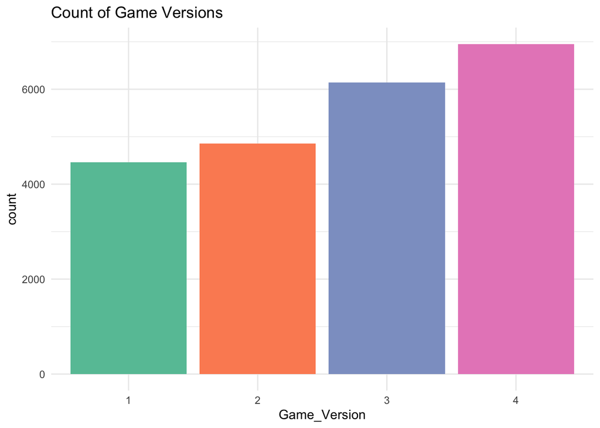

```r
# Bar Plot for Game Version
ggplot(data, aes(x = Game_Version)) +
  geom_bar(fill = brewer.pal(4, "Set2")) +
  theme_minimal() +
  ggtitle("Count of Game Versions")
```

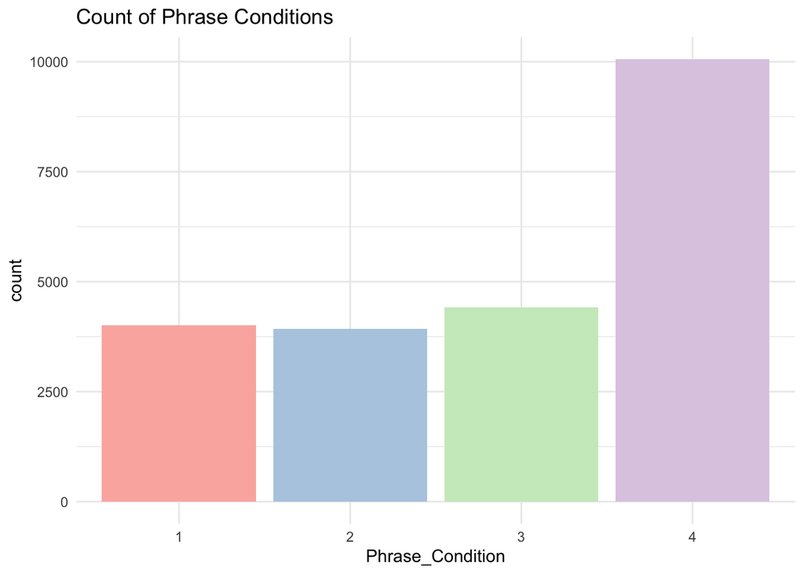

```r
# Bar Plot for Phrase Condition
ggplot(data, aes(x = Phrase_Condition)) +
  geom_bar(fill = brewer.pal(4, "Pastel1")) +
  theme_minimal() +
  ggtitle("Count of Phrase Conditions")
```

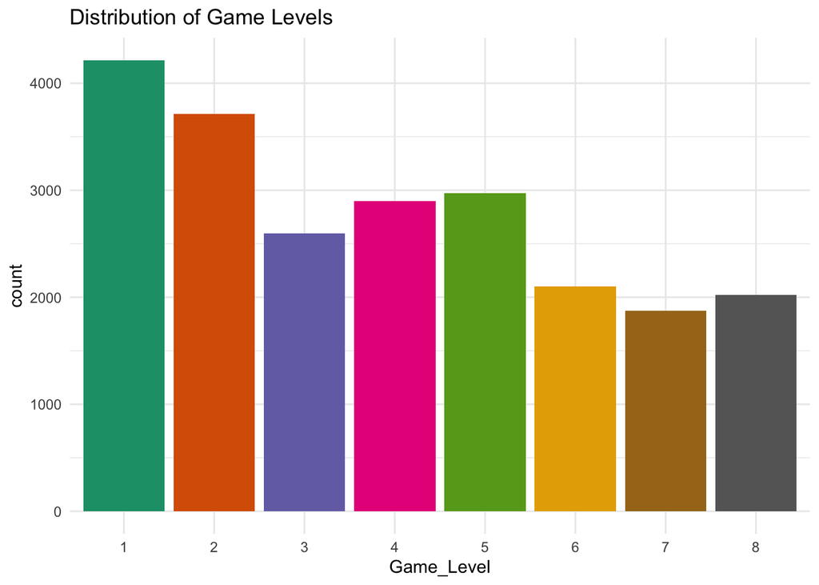

```r
# Bar Plot for Game Level
ggplot(data, aes(x = Game_Level)) +
  geom_bar(fill = brewer.pal(8, "Dark2")) +
  theme_minimal() +
  ggtitle("Distribution of Game Levels")
```

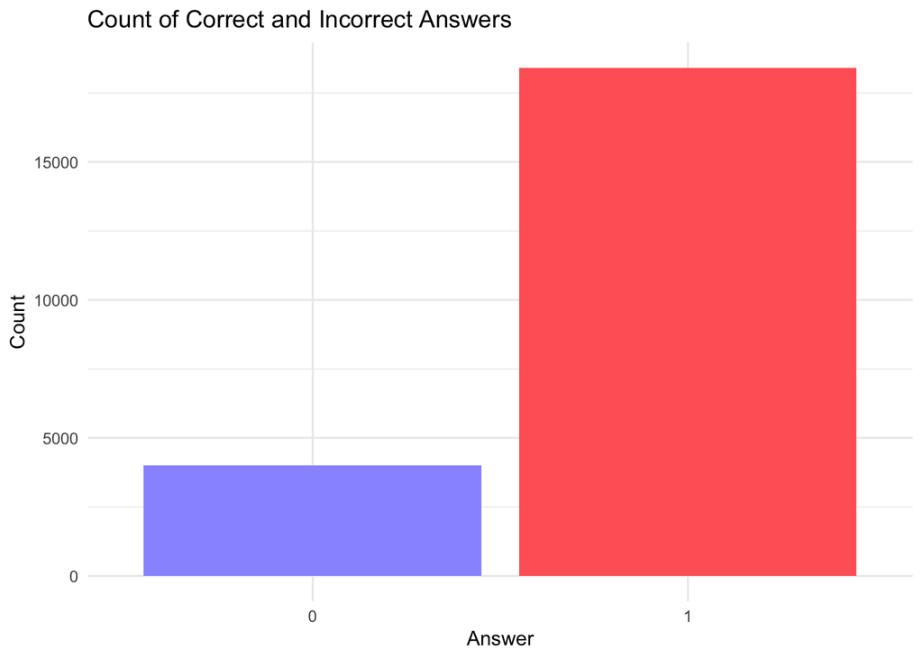

```r
# Bar Plot for Answer using numeric values as factors, without a legend
ggplot(data, aes(x = as.factor(Answer), fill = as.factor(Answer))) +
  geom_bar() +
  scale_fill_manual(values = c("1" = "#FF6666", "0" = "#9999FF")) +
  theme_minimal() +
  theme(legend.position = "none") +  # Hides the legend
  ggtitle("Count of Correct and Incorrect Answers") +
  xlab("Answer") + ylab("Count")
```

## Raw Distributions of numerical variables

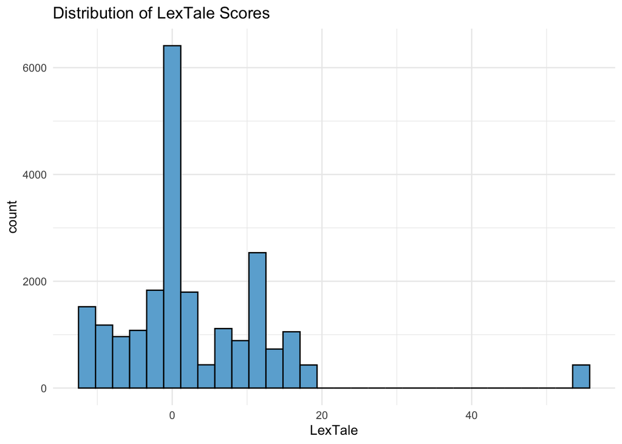

```r
# Distribution of LexTale
ggplot(data, aes(x = LexTale)) +
  geom_histogram(bins = 30, fill = brewer.pal(9, "Blues")[5], color = "black") +
  theme_minimal() +
  ggtitle("Distribution of LexTale Scores")
```

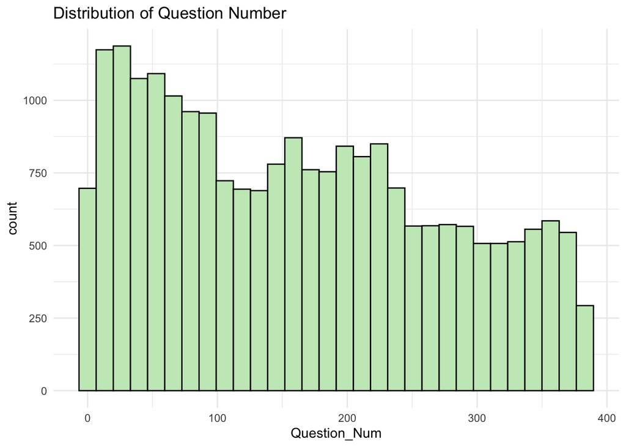

```r
# Distribution of Question_Num
ggplot(data, aes(x = Question_Num)) +
  geom_histogram(bins = 30, fill = brewer.pal(9, "Greens")[3], color = "black") +
  theme_minimal() +
  ggtitle("Distribution of Question Number")
```

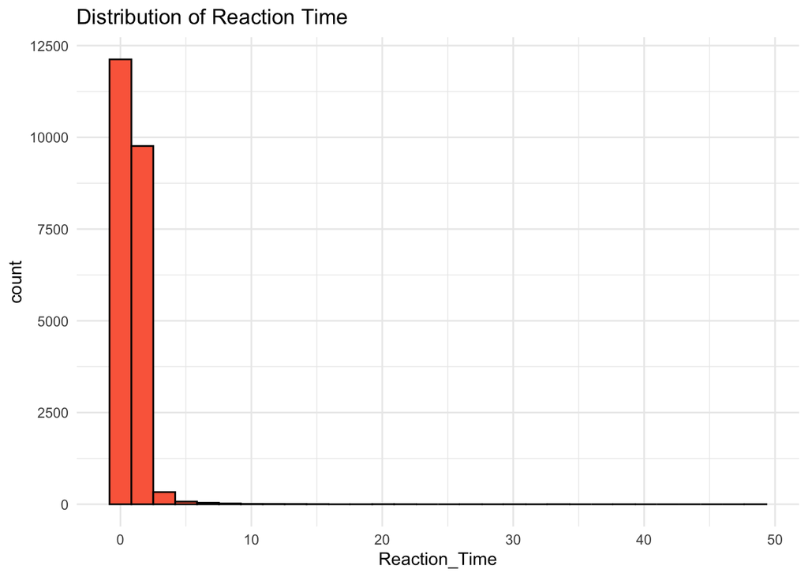

```r
# Distribution of Reaction Time
ggplot(data, aes(x = Reaction_Time)) +
  geom_histogram(bins = 30, fill = brewer.pal(9, "Reds")[5], color = "black") +
  theme_minimal() +
  ggtitle("Distribution of Reaction Time")
```

There are outliers in the LexTale and the Reaction Time distributions.

## Let’s filter outliers for reaction time.

### Outlier testing on Reaction Time

```r
# Calculate the quartiles and IQR
Q1 <- quantile(data$Reaction_Time, 0.25, na.rm = TRUE)
Q3 <- quantile(data$Reaction_Time, 0.75, na.rm = TRUE)
IQR <- Q3 - Q1

# Define bounds
lower_bound <- Q1 - 1.5 * IQR
upper_bound <- Q3 + 1.5 * IQR

# Filter outliers
filtered_data <- data[data$Reaction_Time >= lower_bound & data$Reaction_Time <= upper_bound, ]

write.csv(filtered_data, "filtered_data.csv")

# Checking the effect of outlier removal
original_n <- nrow(data)
filtered_n <- nrow(filtered_data)
cat("Original data had", original_n, "observations.\n")
```

```
## Original data had 22404 observations.
```

```r
cat("Filtered data has", filtered_n, "observations.\n")
```

```
## Filtered data has 21488 observations.
```

```r
cat("Number of outliers removed:", original_n - filtered_n, "\n")
```

```
## Number of outliers removed: 916
```

### Density plots before and after outlier filtering:

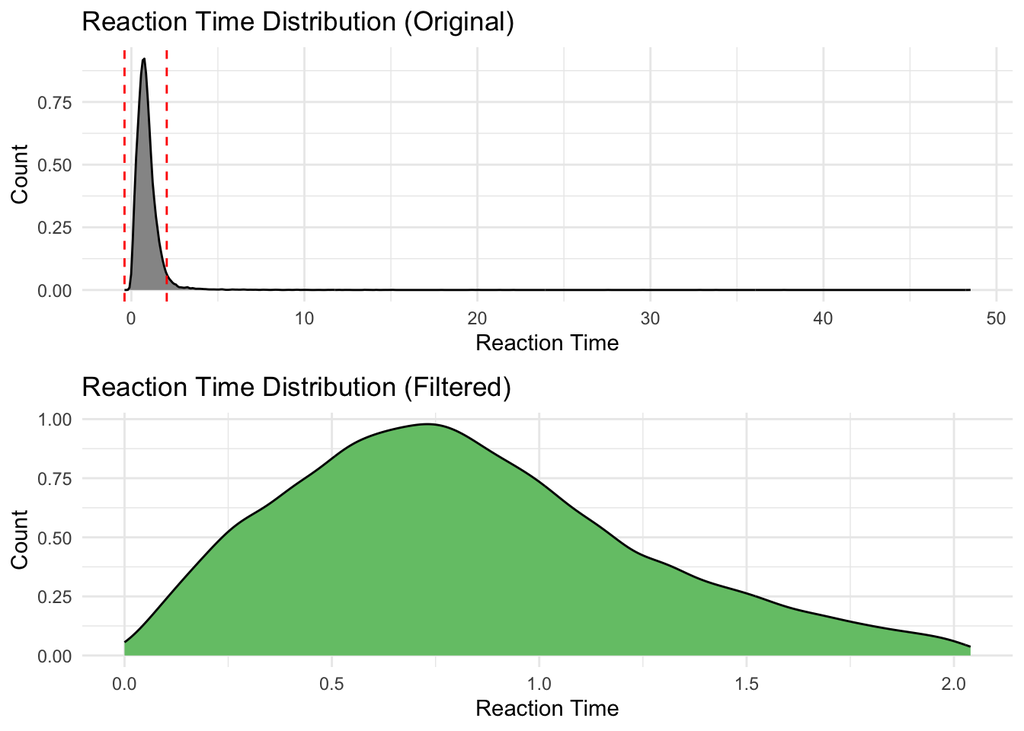

```r
# Plot before outlier removal
p1 <- ggplot(data, aes(x = Reaction_Time)) +
  geom_density(bins = 30, fill = brewer.pal(9, "Greys")[5], color = "black") +
  geom_vline(xintercept = c(lower_bound, upper_bound), color = "red", linetype = "dashed") +
  theme_minimal() +
  ggtitle("Reaction Time Distribution (Original)") +
  xlab("Reaction Time") + ylab("Count")
# Plot after outlier removal
p2 <- ggplot(filtered_data, aes(x = Reaction_Time)) +
  geom_density(bins = 30, fill = brewer.pal(9, "Greens")[5], color = "black") +
  theme_minimal() +
  ggtitle("Reaction Time Distribution (Filtered)") +
  xlab("Reaction Time") + ylab("Count")
# Display plots in a grid
grid.arrange(p1, p2, nrow = 2)
```

### Check for normality:

```r
# Generate a normally distributed dataset
set.seed(123)  # For reproducibility
normal_data <- rnorm(1000, mean = 50, sd = 10)  # 1000 data points, mean = 50, sd = 10

# Perform the Anderson-Darling test on this normally distributed data
ad_result <- ad.test(normal_data)

# Print the results of the Anderson-Darling test for the synthetic normal data
print("Anderson-Darling test results for synthetic normal data:")
```

```
## [1] "Anderson-Darling test results for synthetic normal data:"
```

```r
print(ad_result)
```

```
##
##  Anderson-Darling normality test
##
## data:  normal_data
## A = 0.29653, p-value = 0.592
```

```r
# Now perform the Anderson-Darling test on the Reaction_Time from filtered_data
ad_result_filtered <- ad.test(filtered_data$Reaction_Time)

# Print the results of the Anderson-Darling test for the filtered data
print("Anderson-Darling test results for filtered Reaction_Time data:")
```

```
## [1] "Anderson-Darling test results for filtered Reaction_Time data:"
```

```r
print(ad_result_filtered)
```

```
##
##  Anderson-Darling normality test
##
## data:  filtered_data$Reaction_Time
## A = 122.47, p-value < 2.2e-16
```

Filtered Reaction Time Data: A Statistic (A = 122.47): This very high value indicates a strong departure from normality. P-value (< 2.2e-16): An extremely low p-value strongly rejects the null hypothesis that the Reaction_Time data are normally distributed, suggesting significant deviations from a normal distribution. The filtered Reaction_Time data significantly deviate from normality, suggesting that either the data inherently possess non-normal characteristics or that the process of filtering did not achieve normality, necessitating further investigation or the use of non-parametric statistical methods for analysis. We should use non-parametric tests moving forward…

## After filtering let’s look at distributions of everything one last time:

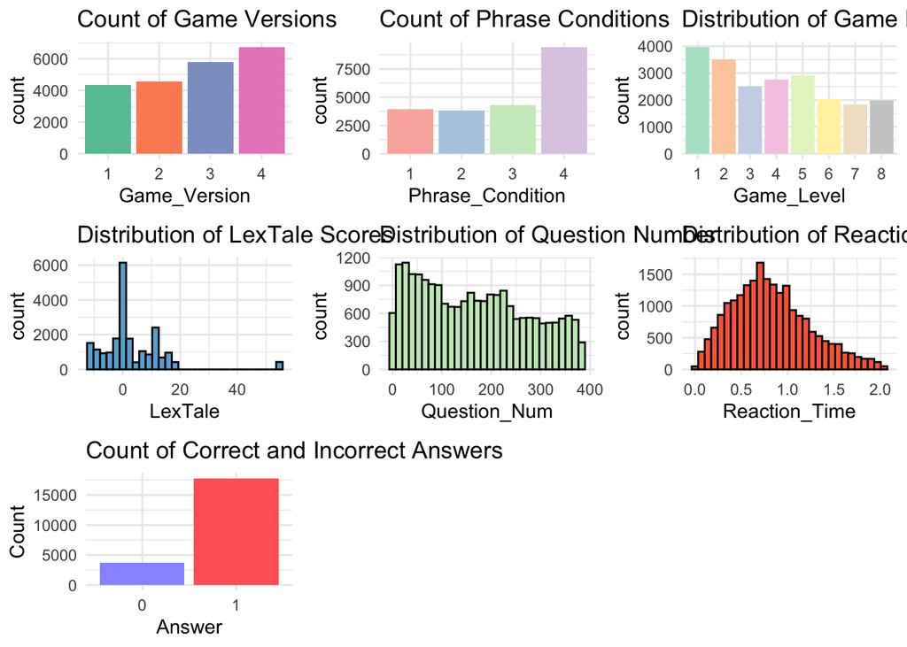

```r
# Bar Plot for Game Version
p1 <- ggplot(filtered_data, aes(x = Game_Version)) +
  geom_bar(fill = brewer.pal(4, "Set2")) +
  theme_minimal() +
  ggtitle("Count of Game Versions")

# Bar Plot for Phrase Condition
p2 <- ggplot(filtered_data, aes(x = Phrase_Condition)) +
  geom_bar(fill = brewer.pal(4, "Pastel1")) +
  theme_minimal() +
  ggtitle("Count of Phrase Conditions")

# Bar Plot for Game Level
p3 <- ggplot(filtered_data, aes(x = Game_Level)) +
  geom_bar(fill = brewer.pal(8, "Pastel2")) +
  theme_minimal() +
  ggtitle("Distribution of Game Levels")

# Distribution of LexTale
p4 <- ggplot(filtered_data, aes(x = LexTale)) +
  geom_histogram(bins = 30, fill = brewer.pal(9, "Blues")[5], color = "black") +
  theme_minimal() +
  ggtitle("Distribution of LexTale Scores")

# Distribution of Question Number
p5 <- ggplot(filtered_data, aes(x = Question_Num)) +
  geom_histogram(bins = 30, fill = brewer.pal(9, "Greens")[3], color = "black") +
  theme_minimal() +
  ggtitle("Distribution of Question Number")

# Distribution of Reaction Time
p6 <- ggplot(filtered_data, aes(x = Reaction_Time)) +
  geom_histogram(bins = 30, fill = brewer.pal(9, "Reds")[5], color = "black") +
  theme_minimal() +
  ggtitle("Distribution of Reaction Time")

# Bar Plot for Answer using numeric values as factors, without a legend
p7 <- ggplot(filtered_data, aes(x = as.factor(Answer), fill = as.factor(Answer))) +
  geom_bar() +
  scale_fill_manual(values = c("1" = "#FF6666", "0" = "#9999FF")) +
  theme_minimal() +
  theme(legend.position = "none") +  # Hides the legend
  ggtitle("Count of Correct and Incorrect Answers") +
  xlab("Answer") + ylab("Count")

# Arrange the plots in a grid
grid.arrange(p1, p2, p3, p4, p5, p6, p7, nrow = 3, ncol = 3)
```

## Okay let’s look some basic trends

### Reaction time vs. Question Number

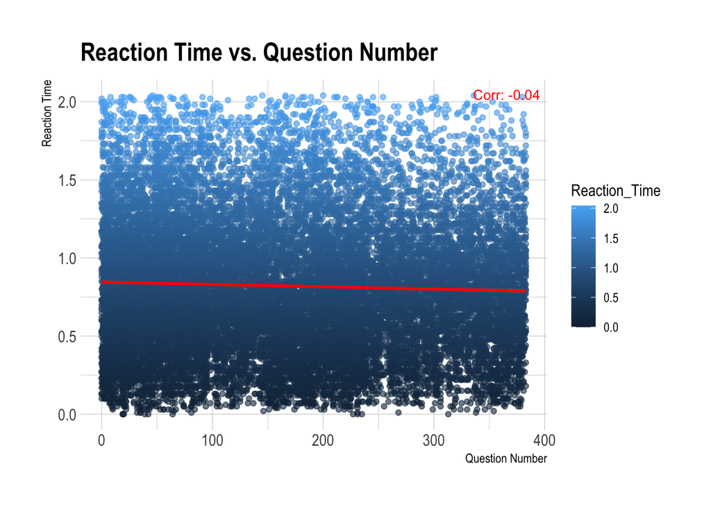

```r
# Calculate the correlation coefficients
cor_reaction_time <- cor(filtered_data$Question_Num, filtered_data$Reaction_Time, use = "complete.obs")

# Plot for Reaction Time vs. Question Number
ggplot(filtered_data, aes(x=Question_Num, y=Reaction_Time)) +
  geom_point(aes(color = Reaction_Time), alpha = 0.6) +  # Points with color based on value
  geom_smooth(method=lm, color="red", fill="#69b3a2", se=TRUE) +  # Linear regression with confidence interval
  annotate("text", x = Inf, y = Inf, label = sprintf("Corr: %.2f", cor_reaction_time),
           hjust = 1.1, vjust = 2, size = 3.5, color = "red") +  # Add correlation value
  theme_ipsum() +
  ggtitle("Reaction Time vs. Question Number") +
  xlab("Question Number") + ylab("Reaction Time")
```

Looks like there is no obvious trend between reaction time and question number.

### Reaction Time vs. Answer Type

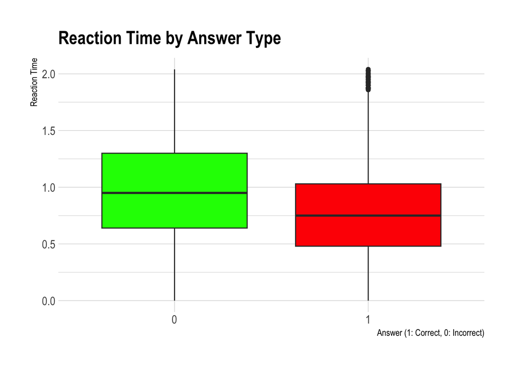

```r
# Box Plot for Reaction Time vs. Answer
ggplot(filtered_data, aes(x = as.factor(Answer), y = Reaction_Time, fill = as.factor(Answer))) +
  geom_boxplot() +
  scale_fill_manual(values = c("1" = "red", "0" = "green")) +
  theme_ipsum() +
  theme(legend.position = "none") +
  ggtitle("Reaction Time by Answer Type") +
  xlab("Answer (1: Correct, 0: Incorrect)") + ylab("Reaction Time")
```

Wonder if these differences are significant…

## Wilcoxon Rank-Sum Test for Reaction Time

```r
# Wilcoxon Rank-Sum Test for Reaction Time
# Filtered data should be used for reaction time if you're comparing groups post filtering
wilcox.test(Reaction_Time ~ as.factor(Answer), data = filtered_data, alternative = "two.sided")
```

```
##
##  Wilcoxon rank sum test with continuity correction
##
## data:  Reaction_Time by as.factor(Answer)
## W = 41111922, p-value < 2.2e-16
## alternative hypothesis: true location shift is not equal to 0
```

The test results support the alternative hypothesis that there is a nonzero difference between the median reaction times of the two groups. In practical terms, this means one group (either those who answered correctly or incorrectly) tends to have higher or lower reaction times than the other.

## Checking correlations between numeric variables

```r
cor_matrix <- cor(filtered_data[c("LexTale", "Question_Num", "Reaction_Time")], use = "complete.obs")
print(cor_matrix)
```

```
##                    LexTale Question_Num Reaction_Time
## LexTale        1.000000000   0.08952161  -0.008754131
## Question_Num   0.089521613   1.00000000  -0.039186767
## Reaction_Time -0.008754131  -0.03918677   1.000000000
```

## Checking Chi-squared test for for independence between categorical variables

```r
# Chi-squared test for independence between categorical variables
chisq.test(table(filtered_data$Game_Version, filtered_data$Phrase_Condition))
```

```
##
##  Pearson's Chi-squared test
##
## data:  table(filtered_data$Game_Version, filtered_data$Phrase_Condition)
## X-squared = 182.15, df = 9, p-value < 2.2e-16
```

Variables are not independent…we know that….

## Using the github examples

```r
# Descriptive statistics for Reaction Time and Answer
# Summarize Reaction Time by Game Version, Game Level, and Phrase Condition
RT_summary <- filtered_data %>%
  group_by(Game_Version, Phrase_Condition) %>%
  summarize(Mean_RT = mean(Reaction_Time, na.rm = TRUE), .groups = "drop")

# Calculate accuracy percentage for each group
accuracy_summary <- filtered_data %>%
  group_by(Game_Version, Phrase_Condition) %>%
  summarize(Accuracy_Percentage = mean(as.numeric(Answer)), .groups = "drop")

RT_summary
```

```
## # A tibble: 16 × 3
##    Game_Version Phrase_Condition Mean_RT
##    <fct>        <fct>              <dbl>
##  1 1            1                  0.655
##  2 1            2                  0.790
##  3 1            3                  0.593
##  4 1            4                  0.983
##  5 2            1                  0.640
##  6 2            2                  0.950
##  7 2            3                  0.759
##  8 2            4                  1.06
##  9 3            1                  0.592
## 10 3            2                  0.908
## 11 3            3                  0.728
## 12 3            4                  1.00
## 13 4            1                  0.624
## 14 4            2                  0.743
## 15 4            3                  0.596
## 16 4            4                  0.866
```

```r
accuracy_summary
```

```
## # A tibble: 16 × 3
##    Game_Version Phrase_Condition Accuracy_Percentage
##    <fct>        <fct>                          <dbl>
##  1 1            1                              0.963
##  2 1            2                              0.936
##  3 1            3                              0.962
##  4 1            4                              0.730
##  5 2            1                              0.954
##  6 2            2                              0.915
##  7 2            3                              0.868
##  8 2            4                              0.711
##  9 3            1                              0.971
## 10 3            2                              0.915
## 11 3            3                              0.907
## 12 3            4                              0.678
## 13 4            1                              0.963
## 14 4            2                              0.898
## 15 4            3                              0.921
## 16 4            4                              0.684
```

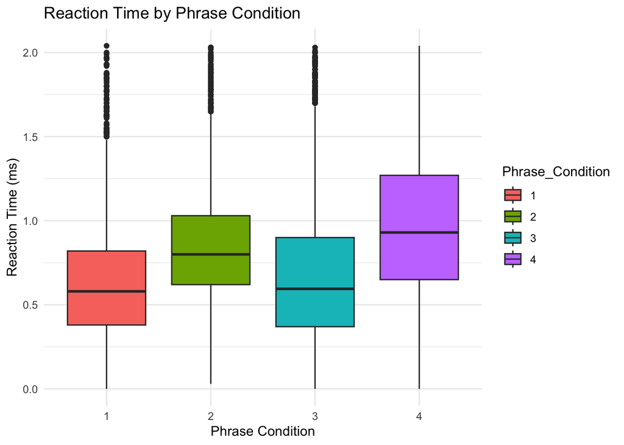

```r
# Plotting Reaction Time across Phrase Conditions
ggplot(filtered_data, aes(x = Phrase_Condition, y = Reaction_Time, group = Phrase_Condition, fill = Phrase_Condition)) +
  geom_boxplot() +
  labs(title = "Reaction Time by Phrase Condition", x = "Phrase Condition", y = "Reaction Time (ms)") +
  theme_minimal()
```

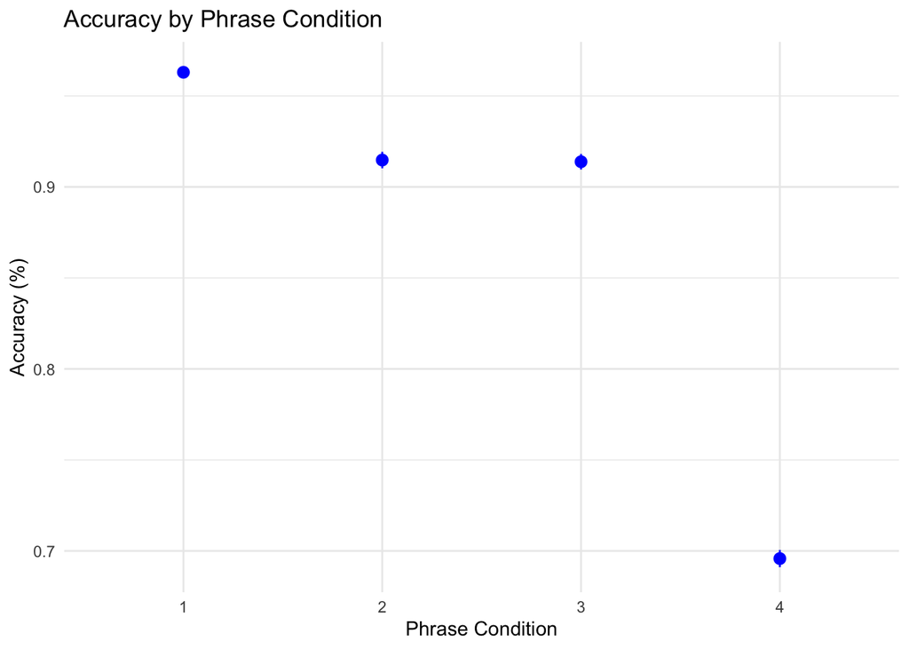

```r
# Plotting Accuracy across Phrase Conditions
ggplot(filtered_data, aes(x = Phrase_Condition, y = Answer, group = Phrase_Condition)) +
  stat_summary(fun.data = mean_se, geom = "pointrange", color = "blue") +
  labs(title = "Accuracy by Phrase Condition", x = "Phrase Condition", y = "Accuracy (%)") +
  theme_minimal()
```

### Look in detail at LaxTale scores, distribution, trends, outliers

### Consider different transformations to meet normality assumptions.

### Effect Size: It could be beneficial to calculate an effect size, like Cliff’s Delta, to understand the magnitude of the difference between groups.